# lab01_assignment3

2025-11-19

## Assignment 3. Logistic regression and basis function

### 3.1 Scatterplot showing a Plasma glucose concentration on Age

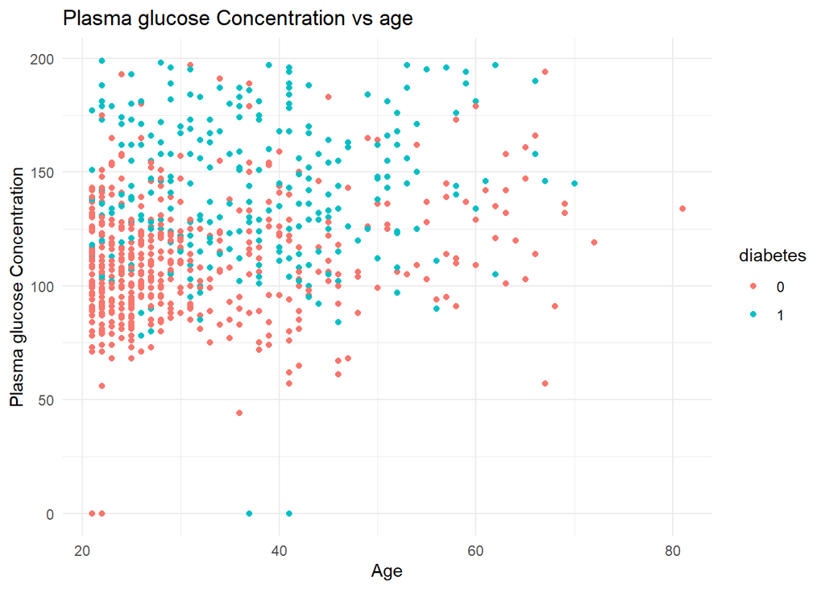

**Comments**

The scatterplot shows that glucose and age do relate to diabetes, but the two classes overlap a lot. This means it is not easy to classify diabetes using only these two variables with a simple logistic regression model.

### 3.2 Train a logistic regression model

```
##
## Call:
## glm(formula = diabetes ~ glucose + age, family = binomial, data = df)
##
## Coefficients:
##              Estimate Std. Error z value Pr(>|z|)
## (Intercept) -5.912449   0.462620  -12.78  < 2e-16 ***
## glucose      0.035644   0.003290   10.83  < 2e-16 ***
## age          0.024778   0.007374    3.36 0.000778 ***
## ---
## Signif. codes:  0 '***' 0.001 '**' 0.01 '*' 0.05 '.' 0.1 ' ' 1
##
## (Dispersion parameter for binomial family taken to be 1)
##
##     Null deviance: 993.48  on 767  degrees of freedom
## Residual deviance: 797.36  on 765  degrees of freedom
## AIC: 803.36
##
## Number of Fisher Scoring iterations: 4
```

```
## Misclassification rate (r = 0.5): 0.263
```

**Probabilistic Model**

$$p(x) = \cfrac{1}{1 + e^{-(-5.912449 +
0.035644x_1 + 0.024778x_2)}}$$
where $x_1$ = Plasma glucose concentration and $x_2$ = age.

**Comments**

The logistic regression model gives a misclassification rate of 0.263, meaning it gets about 74% of the predictions right. The model works reasonably well but makes many mistakes because the classes overlap. This shows that glucose and age alone do not fully separate diabetic and non-diabetic individuals.

### 3.3 Compute boundary line (r = 0.5)

```
## Equation of the decision boundary: glucose =  -0.6951611  * age +  165.8748
```

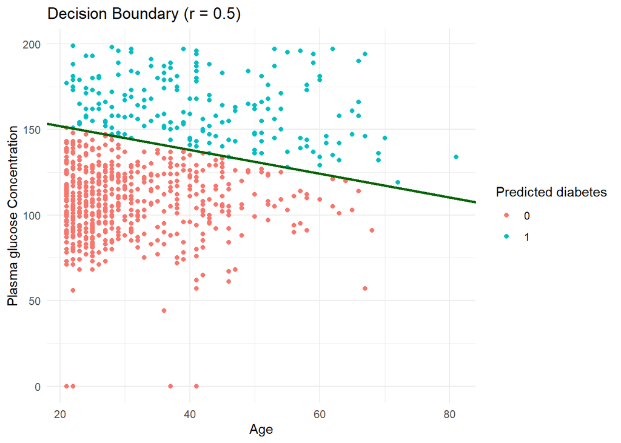

**Comments**

The decision boundary is a straight line, because logistic regression is linear. The line does not perfectly follow how the data is spread out. Many points fall on the wrong side of the boundary, which explains the moderate error rate.

### 3.4 Thresholds r = 0.2 and r = 0.8

```
## Misclassification rate (r = 0.2 ): 0.372
```

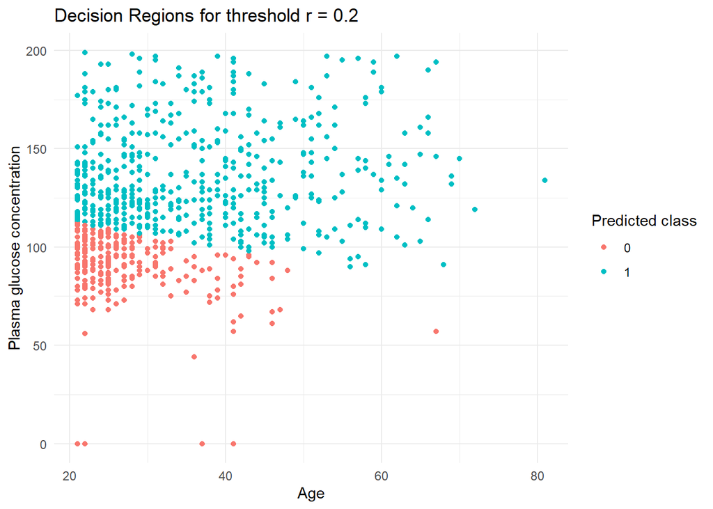

```
## Misclassification rate (r = 0.8 ): 0.315
```

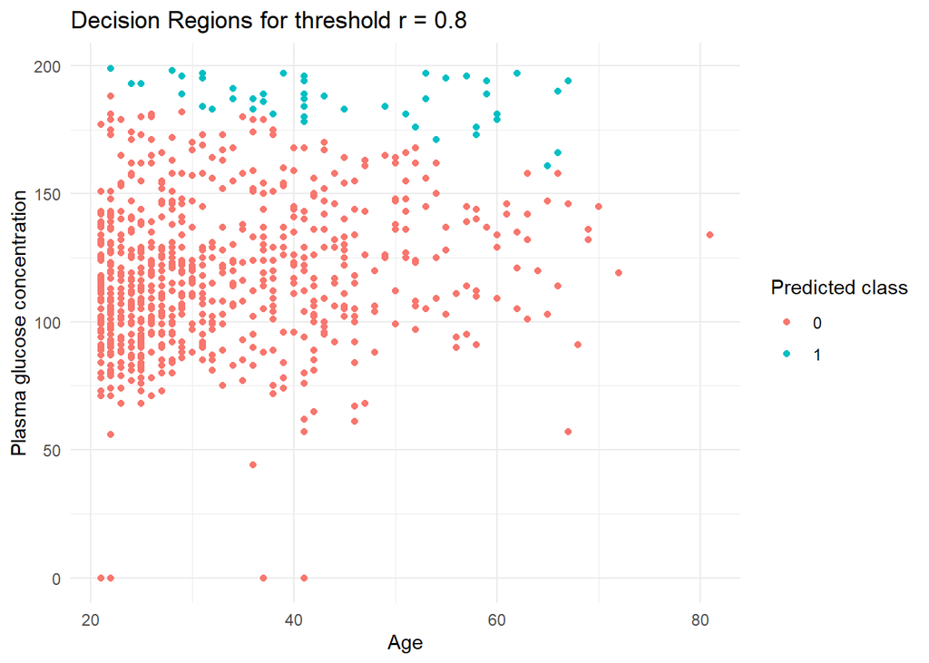

**Comments**

- With r = 0.2, the model predicts more diabetics (many false positives).
- With r = 0.8, the model predicts fewer diabetics (many false negatives).

Changing the threshold does not change the boundary shape but only how strict the model is when deciding between class 0 and class 1.

### 3.5 Basis Expansion (Nonlinear Logistic Regression)

```
##
## Call:
## glm(formula = diabetes ~ glucose + age + z1 + z2 + z3 + z4 +
##     z5, family = binomial, data = df)
##
## Coefficients:
##               Estimate Std. Error z value Pr(>|z|)
## (Intercept) -9.310e+00  1.129e+00  -8.243  < 2e-16 ***
## glucose      3.793e-02  9.473e-03   4.004 6.23e-05 ***
## age          1.457e-01  2.072e-02   7.031 2.05e-12 ***
## z1           1.278e-08  5.610e-09   2.278  0.02271 *
## z2          -1.780e-07  7.635e-08  -2.331  0.01976 *
## z3           8.515e-07  3.437e-07   2.478  0.01322 *
## z4          -1.698e-06  6.313e-07  -2.690  0.00715 **
## z5           8.127e-07  4.054e-07   2.004  0.04503 *
## ---
## Signif. codes:  0 '***' 0.001 '**' 0.01 '*' 0.05 '.' 0.1 ' ' 1
##
## (Dispersion parameter for binomial family taken to be 1)
##
##     Null deviance: 993.48  on 767  degrees of freedom
## Residual deviance: 741.61  on 760  degrees of freedom
## AIC: 757.61
##
## Number of Fisher Scoring iterations: 5
```

```
## Misclassification rate (expanded model, r = 0.5): 0.245
```

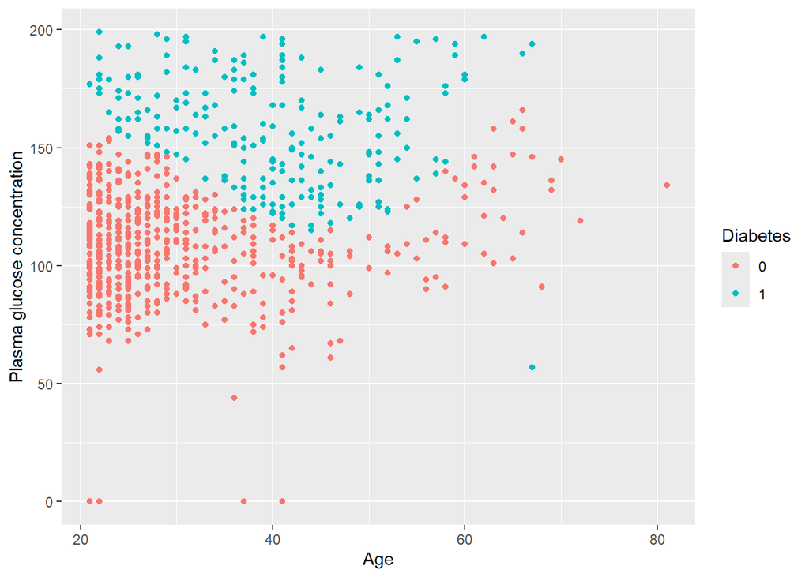

**Comments**

After adding polynomial features, the misclassification rate improves slightly to 0.245. This model is better because it can create a curved, nonlinear decision boundary, which fits the data more closely. The improvement is small, but it shows that the relationship between age, glucose, and diabetes is not purely linear.